# 시계열 2주차 실습

## 1. 패키지 로딩

```r
library(itsmr)
library(MASS)
library(tseries)
library(nortest)
library(forecast)
```

## 2. ACF, PACF

ACF, PACF그래프로 데이터의 자기상관계수과 편자기상관계수를 확인 할 수 있다.  
지난주에 사용한 `AirPassengers`데이터의 ACF과 PACF를 확인해보자

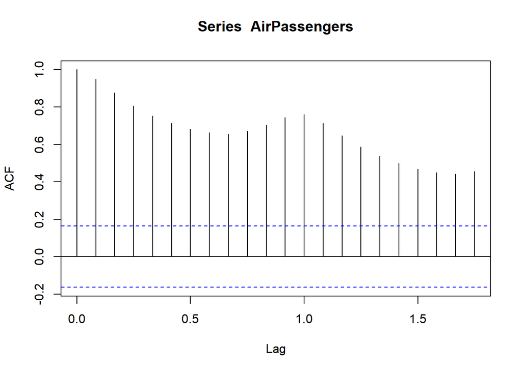

```r
acf(AirPassengers)
```

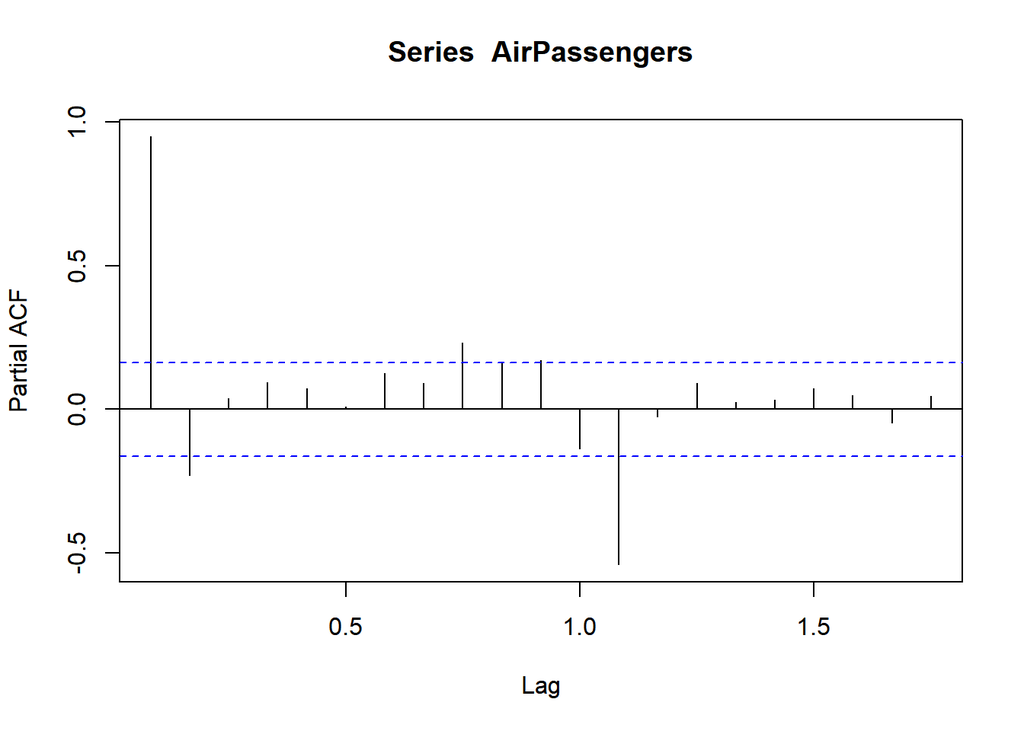

```r
pacf(AirPassengers)
```

## 3. AR, MA

AR모형과 MA모형을 직접 시뮬레이션 해보자  
`arima.sim()`함수를 활용하면 AR, MA, 확률과정을 따르는 데이터를 생성할 수 있다.  
데이터를 직접 생성하여 acf와 pacf를 확인해보자

### AR(1)

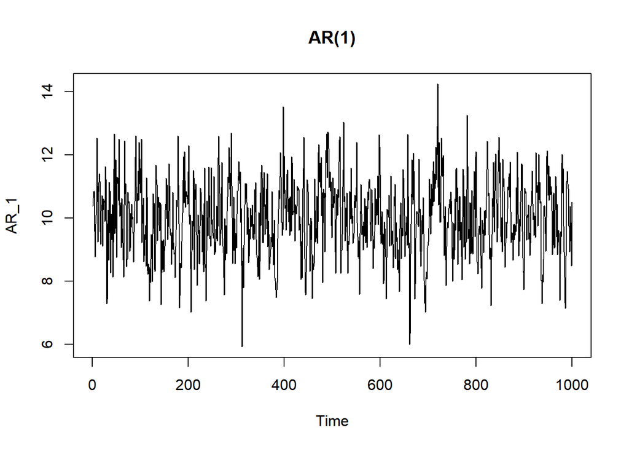

```r
AR_1 <- arima.sim(model = list(order = c(1, 0, 0), ar = c(0.5)), n =1000, mean=5)
plot(AR_1,main="AR(1)")
```

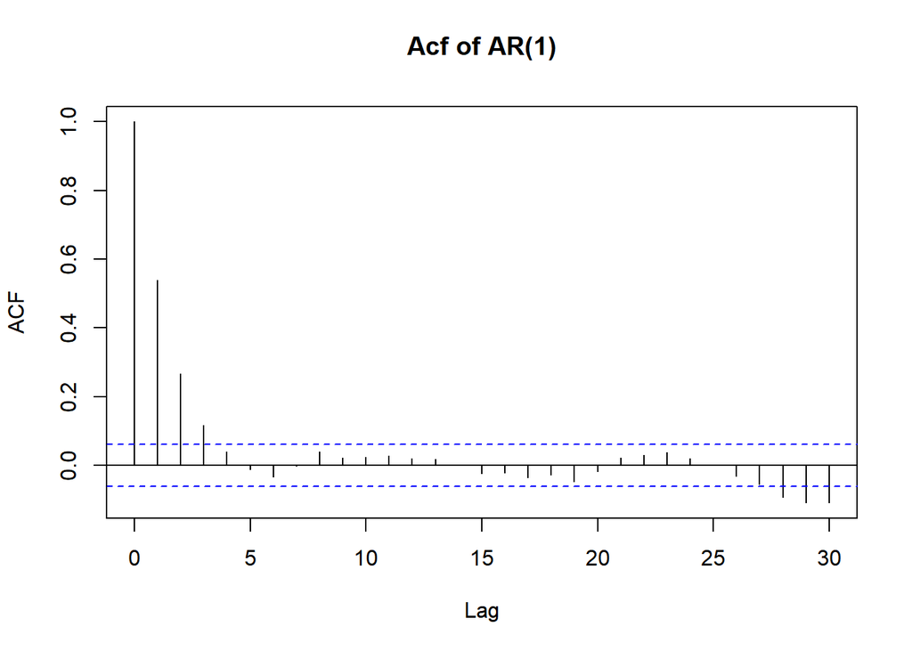

```r
acf(AR_1,main="Acf of AR(1)")
```

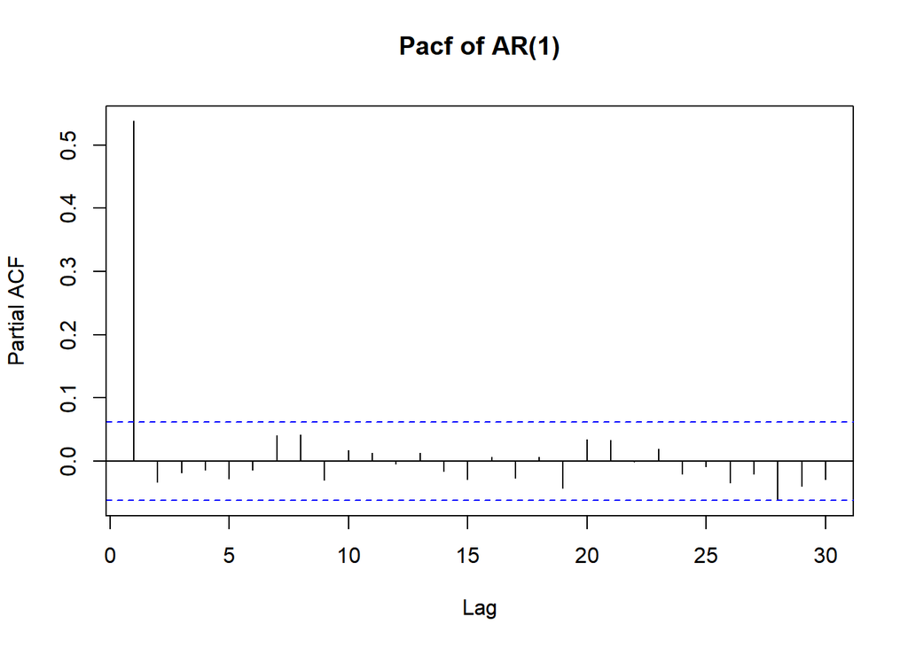

```r
pacf(AR_1,main="Pacf of AR(1)")
```

- acf가 지수적으로 감소하는 모습을 볼 수 있다.
- pacf가 시점 2부터 절단된 모습을 볼 수 있다.

### AR(2)

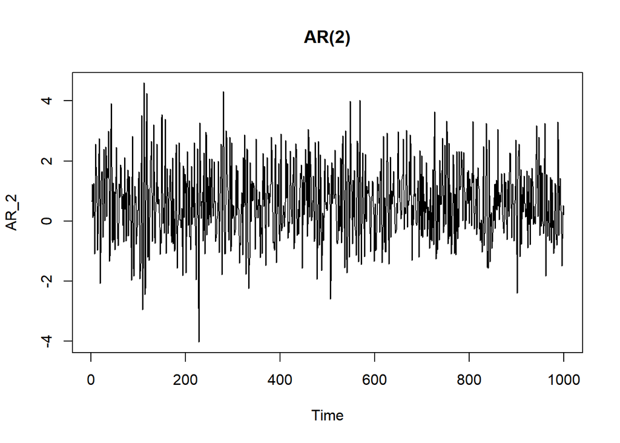

```r
AR_2 <- arima.sim(model = list(order = c(2, 0, 0), ar = c(0.5, -.45)), n =1000, mean=0.6)

plot(AR_2,main="AR(2)")
```

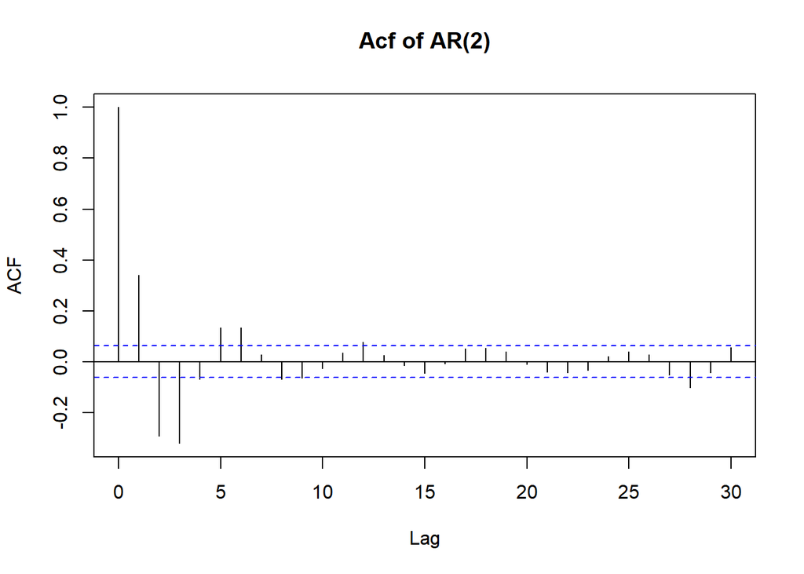

```r
acf(AR_2,main="Acf of AR(2)")
```

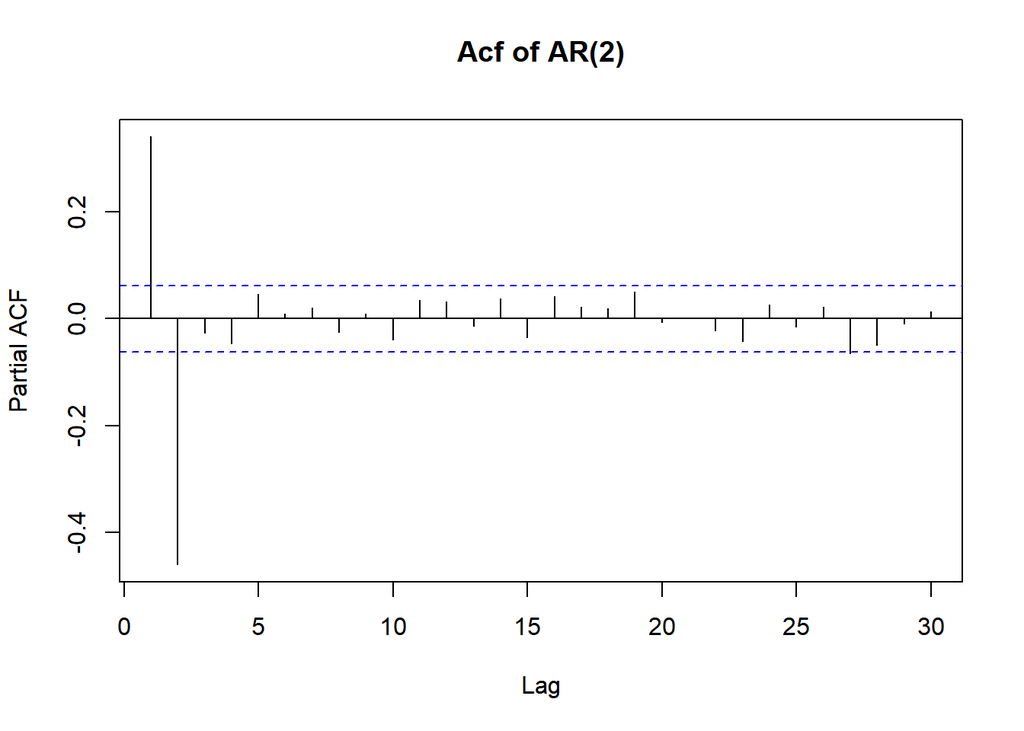

```r
pacf(AR_2,main="Acf of AR(2)")
```

- acf가 지수적으로 감소하는 모습을 볼 수 있다.
- pacf가 시점 3부터 절단된 모습을 볼 수 있다.

### MA(1)

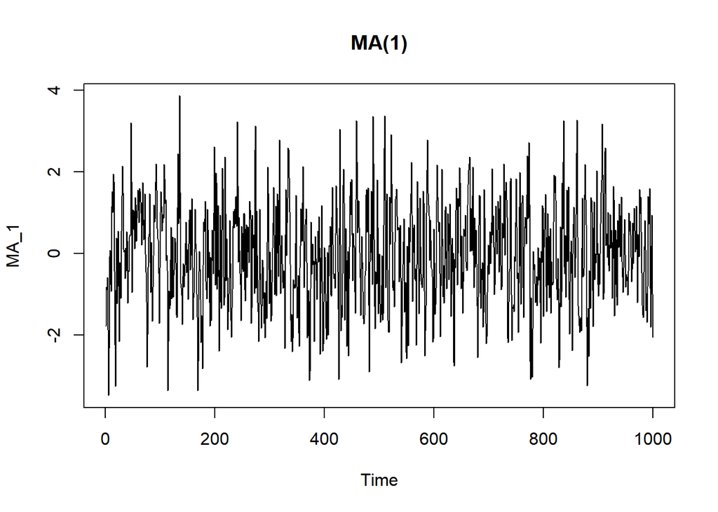

```r
MA_1<-arima.sim(model=list(ma=0.8), n=1000)
plot(MA_1, main="MA(1)")
```

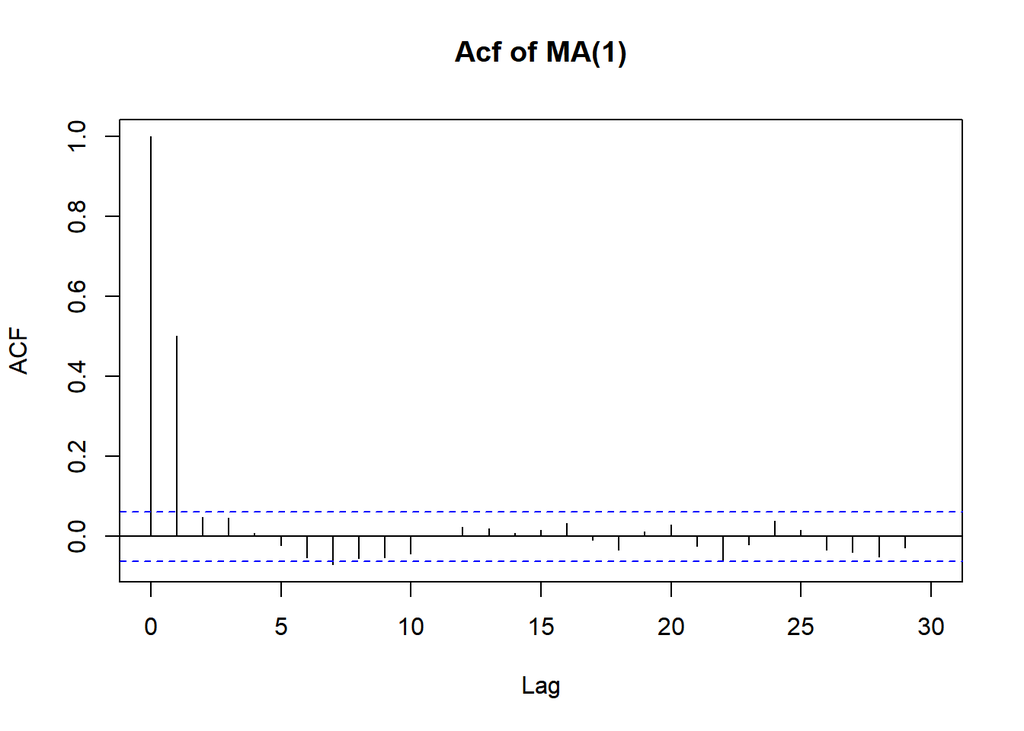

```r
acf(MA_1,main="Acf of MA(1)")
```

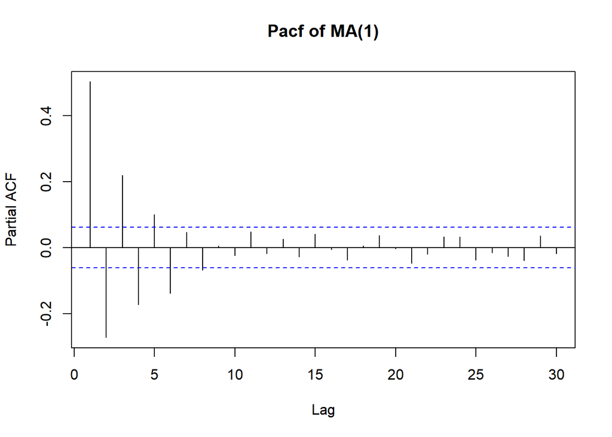

```r
pacf(MA_1,main="Pacf of MA(1)")
```

- acf가 시점 2부터 절단된 모습을 볼 수 있다.
- pacf가 지수적으로 감소하는 모습을 볼 수 있다.

### MA(2)

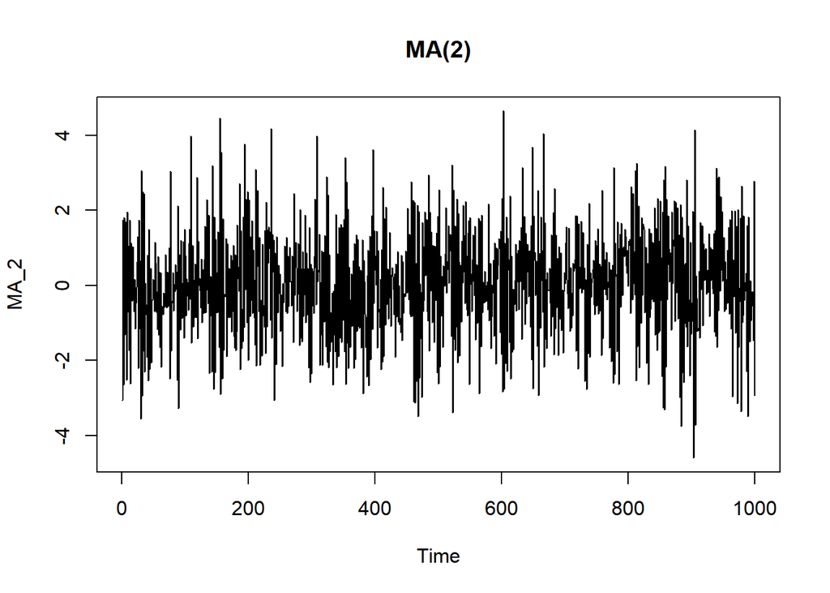

```r
MA_2<-arima.sim(model=list(ma=c(-0.6,0.8)),n=1000)
plot(MA_2, main="MA(2)")
```

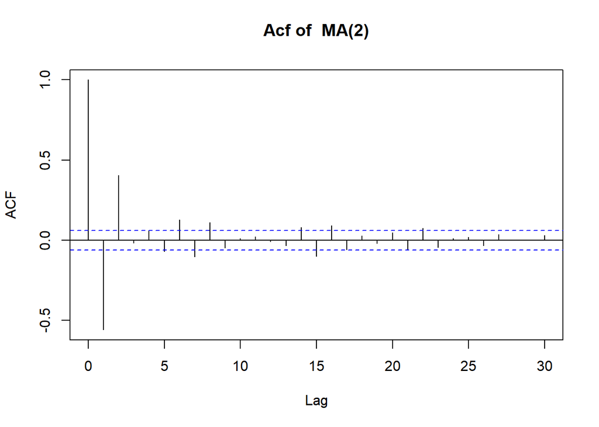

```r
acf(MA_2,main="Acf of  MA(2)")
```

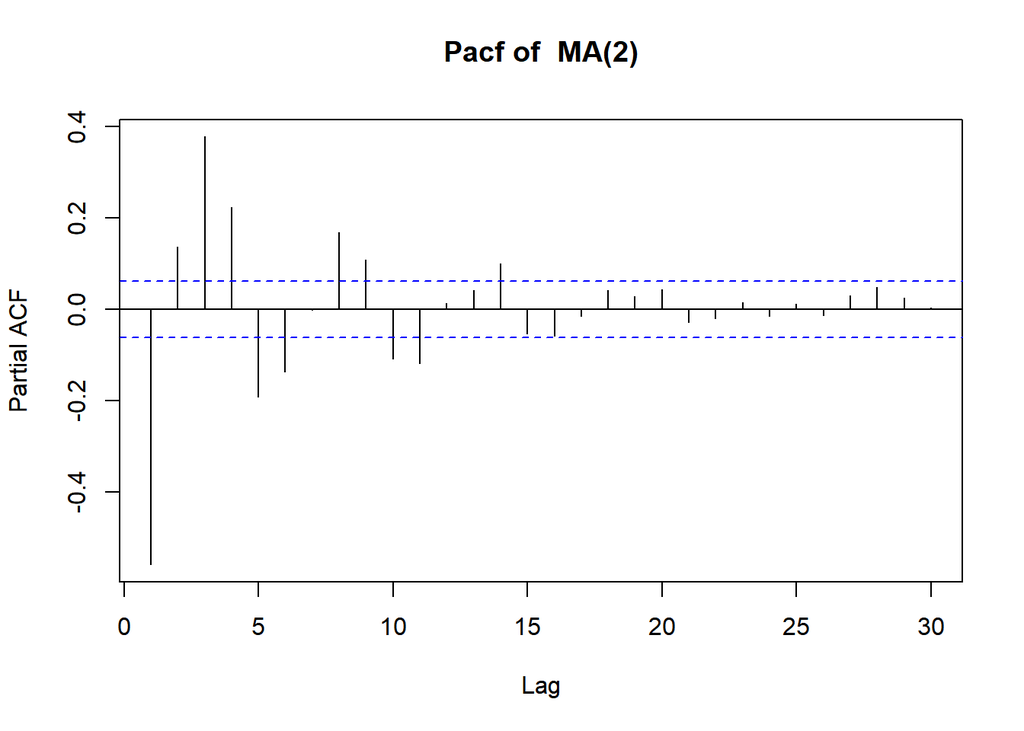

```r
pacf(MA_2,main="Pacf of  MA(2)")
```

- acf가 시점3부터 절단된 모습을 볼 수 있다.
- pacf가 지수적으로 감소하는 모습을 볼 수 있다.

## 4. ARMA

ARMA모형을 직접 시뮬레이션 해보자  
똑같이 `arima.sim()`함수를 활용하면 ARMA확률과정을 따르는 데이터를 생성할 수 있다.  
데이터를 직접 생성하여 acf와 pacf를 확인해보자

### ARMA(1,1)

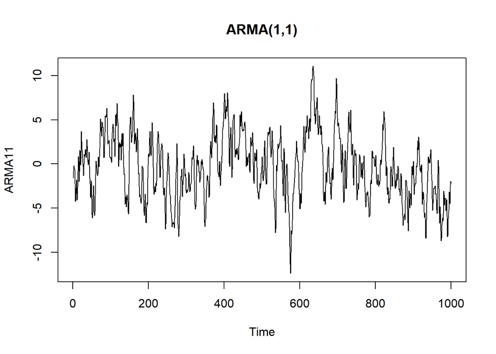

```r
ARMA11 <- arima.sim(model = list(order = c(1, 0, 1), ar = 0.9, ma = .8), n = 1000)
plot(ARMA11,main="ARMA(1,1)")
```

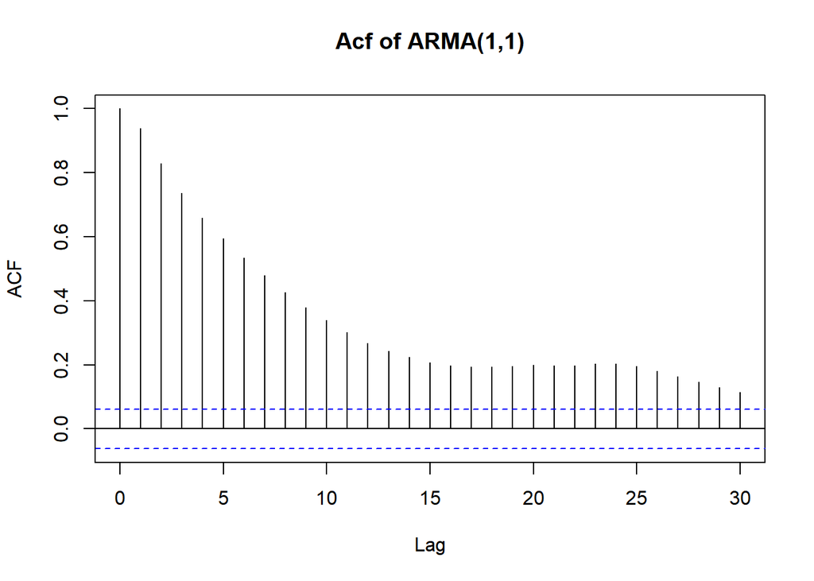

```r
acf(ARMA11,main="Acf of ARMA(1,1)")
```

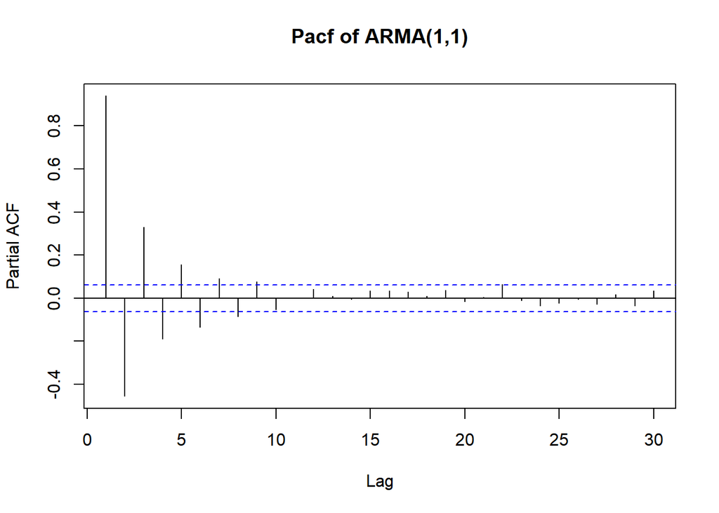

```r
pacf(ARMA11,main="Pacf of ARMA(1,1)")
```

- acf와 pacf가 AR, MA가 혼합된 모습니다
- 둘다 지수적으로 감소하는 모습을 볼 수 있다.

### ARMA(2,1)

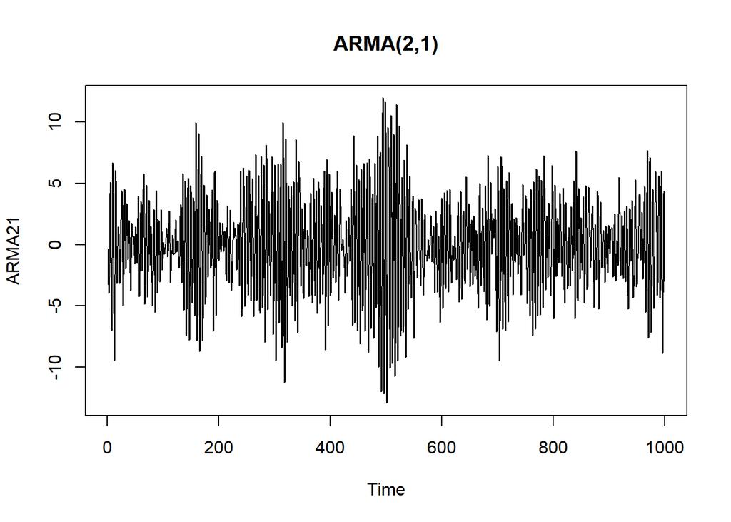

```r
ARMA21 <- arima.sim(model = list(order = c(2, 0, 1), ar=c(0.5, -.9), ma= .8), n=1000)
plot(ARMA21, main="ARMA(2,1)")
```

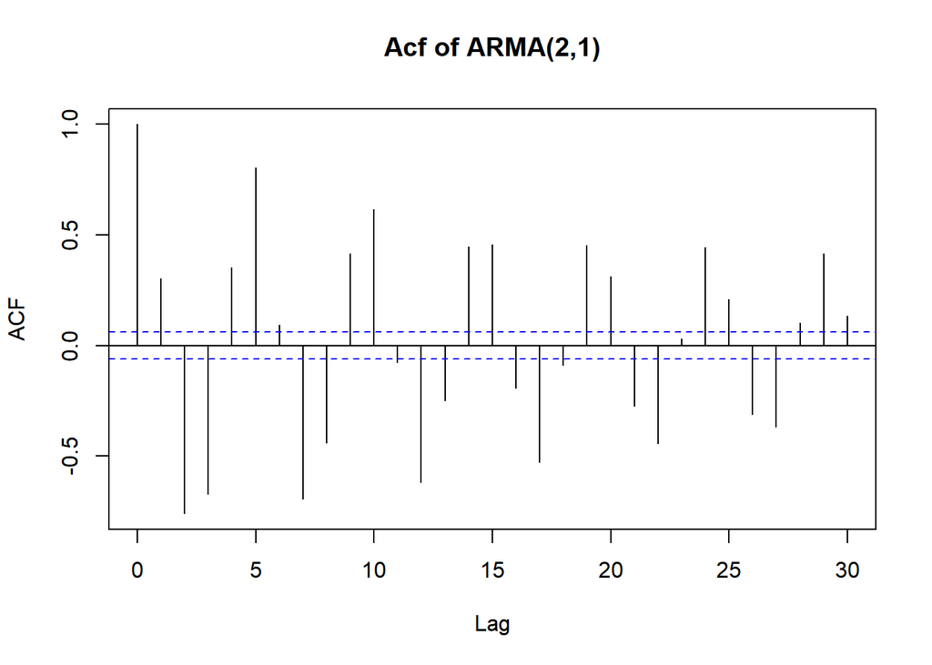

```r
acf(ARMA21, main = "Acf of ARMA(2,1)")
```

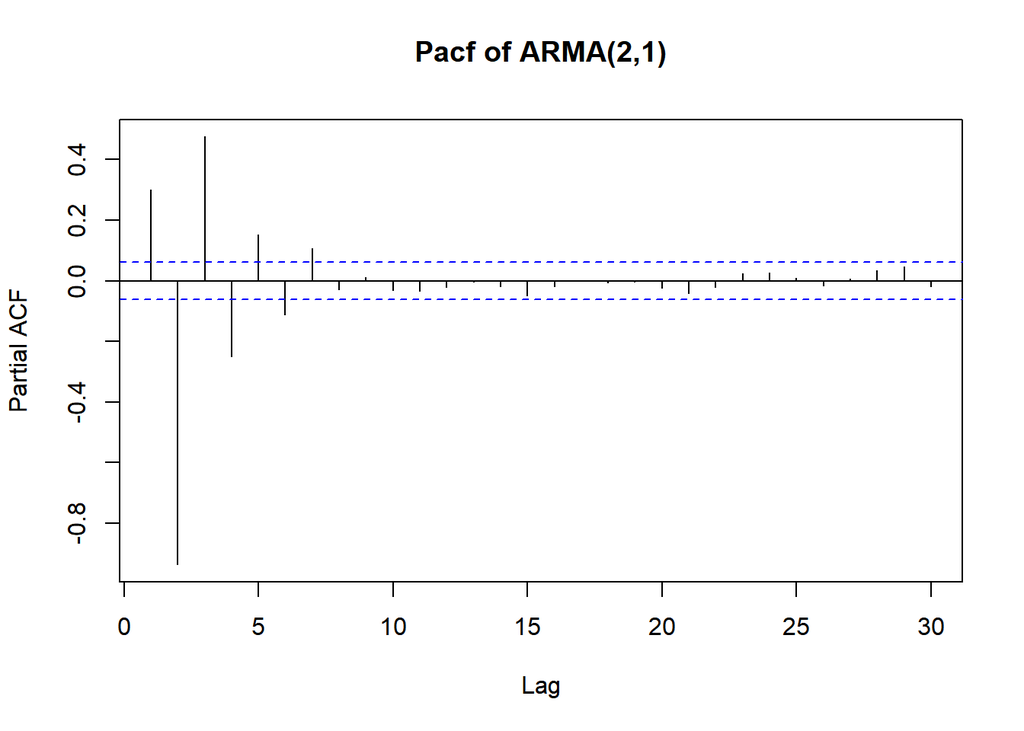

```r
pacf(ARMA21, main = "Pacf of ARMA(2,1)")
```

- acf와 pacf가 AR, MA가 혼합된 모습니다
- 둘다 지수적으로 감소하는 모습을 볼 수 있다.

## 5. 모형 적합

지금 부터는 직접 데이터를 모형에 적합시켜 보자

### (1)라이브러리 불러오기

```r
library(tseries) #for kpss.test()
library(itsmr) #for test()
library(astsa) #for acf2(), sarima.for()
library(lmtest) #for coeftest()
library(forecast)
library(TSA) # 데이터셋
library(nortest)
```

### (2)데이터를 살표보기

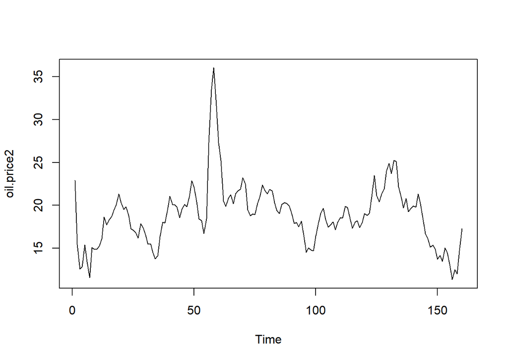

```r
data(oil.price)
oil.price2 = oil.price[1:160]
ts.plot(oil.price2)
```

### (3)정상인지 확인

AR, MA, ARMA모형은 정상 시계열 모델이기에, 데이터가 정상인지 먼저 확인해야 한다.  
1주차때 배웠던 `kpss검정`을 활용하여 정상인지 확인해보자  
`kpss.test`함수를 활용하면 된다.

```r
kpss.test(oil.price2)
```

```
##
##  KPSS Test for Level Stationarity
##
## data:  oil.price2
## KPSS Level = 0.25363, Truncation lag parameter = 4, p-value = 0.1
```

- 귀무가설 기각 못함 -> 정상인거 같음

또한 백색잡음인지도 검정해보자! 백색잡음이면 공분산 행렬이 모두 0이므로, 모델링할 필요가 없다.

```r
Box.test(oil.price2, lag=10,type="Ljung-Box")
```

```
##
##  Box-Ljung test
##
## data:  oil.price2
## X-squared = 368.32, df = 10, p-value < 2.2e-16
```

- 귀무가설 기각 -> 백색잡음 아님

### (4)ACF, PACF

그래프를 통해 어떤 모형이 적합한지, 차수를 결정할 수 있다.

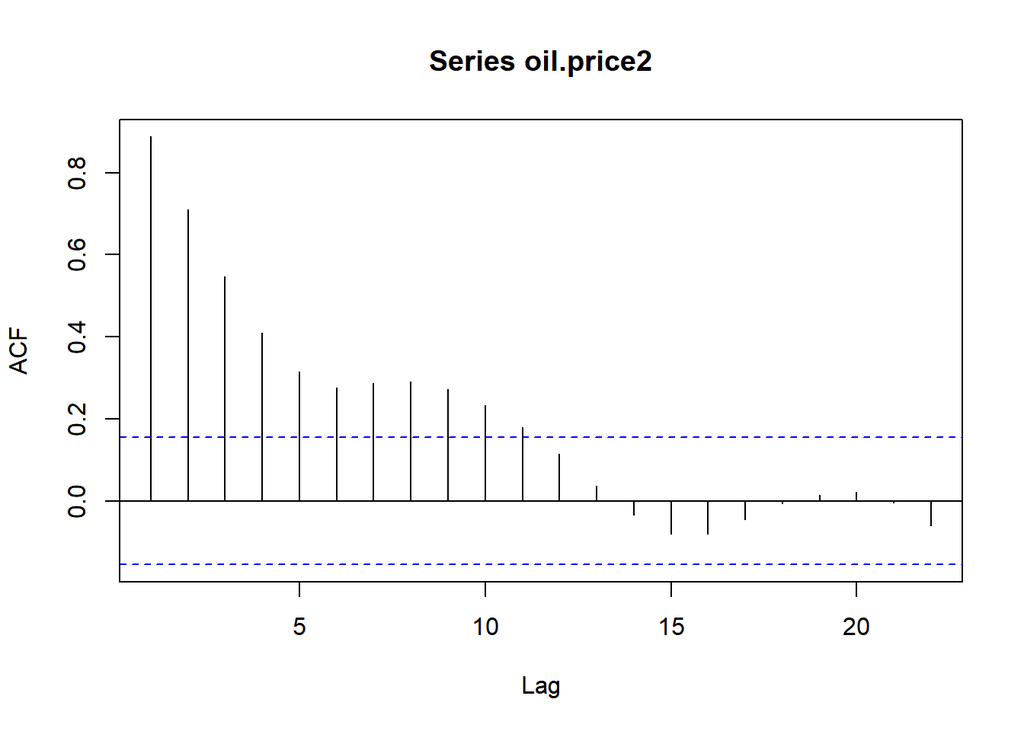

```r
acf(oil.price2)
```

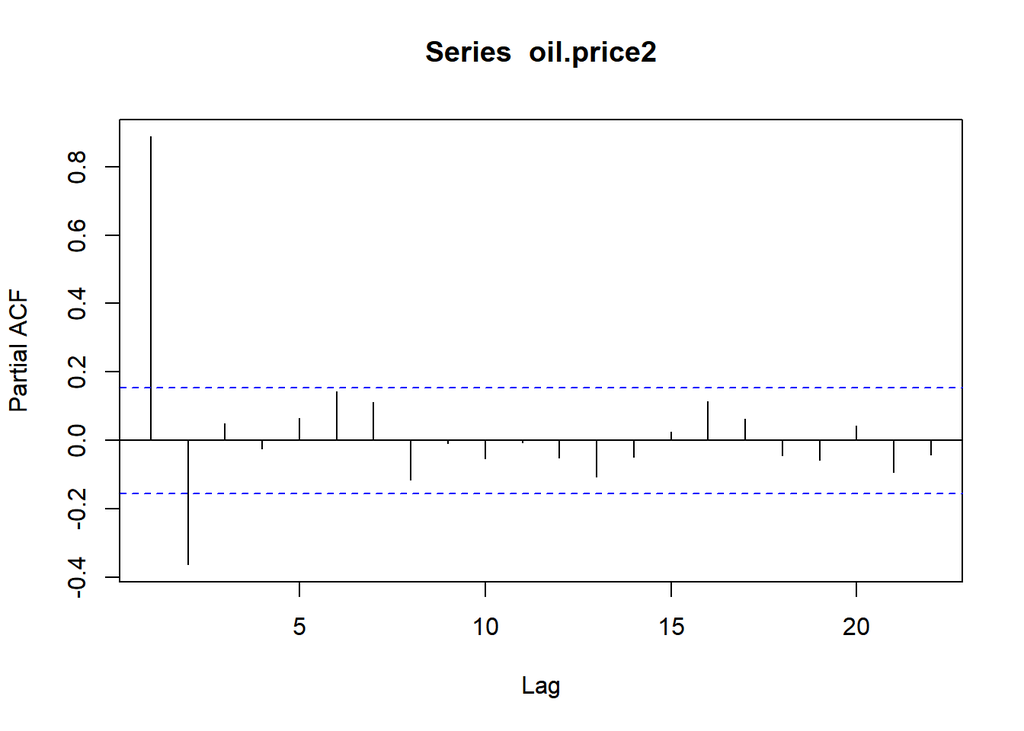

```r
pacf(oil.price2)
```

* acf가 지수적으로 감소하고 pcf가 시점3부터 0이므로, AR(2)모형이 적절해 보인다. * AR(2)를 잠정모형으로 선택하자

### (5)모형 적합

모형을 적합해보자 `arima`함수로 적합할 수 있으며, `order`인자를 통해 차수를 설정해 줄 수 있다.  
`(p,d,q)`순서이며, d는 arima에 나오는 차분 차수이므로 AR, MA모형은 d가 0이다.

```r
fit<-arima(oil.price2, order=c(2,0,0))
summary(fit)
```

```
##
## Call:
## arima(x = oil.price2, order = c(2, 0, 0))
##
## Coefficients:
##          ar1      ar2  intercept
##       1.3267  -0.4835    19.1463
## s.e.  0.0746   0.0750     0.7397
##
## sigma^2 estimated as 2.205:  log likelihood = -291.35,  aic = 588.71
##
## Training set error measures:
```

```
##               ME RMSE MAE MPE MAPE
## Training set NaN  NaN NaN NaN  NaN
```

### (6)모형진단

#### 모형진단

모수의 유의정을 `coeftest`함수를 활용하여 할 수 있다.

```r
coeftest(fit)
```

```
##
## z test of coefficients:
##
##            Estimate Std. Error z value  Pr(>|z|)
## ar1        1.326711   0.074592 17.7862 < 2.2e-16 ***
## ar2       -0.483522   0.074985 -6.4482 1.132e-10 ***
## intercept 19.146313   0.739656 25.8854 < 2.2e-16 ***
## ---
## Signif. codes:  0 '***' 0.001 '**' 0.01 '*' 0.05 '.' 0.1 ' ' 1
```

- 모든 모수가 유의하다.

#### 잔차분석

잔자차 백색잡음인지 확인해보자!

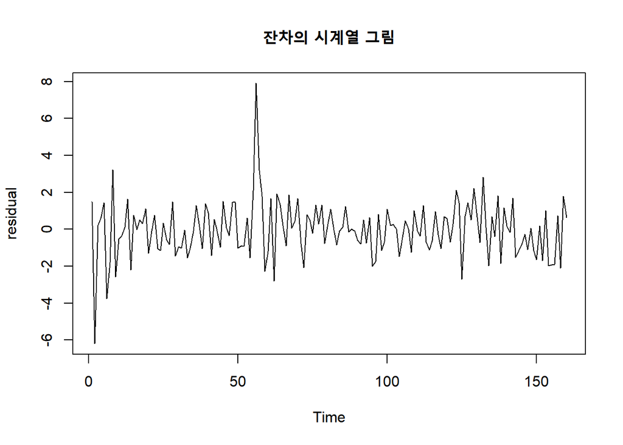

```r
ts.plot(resid(fit),main="잔차의 시계열 그림", ylab="residual")
```

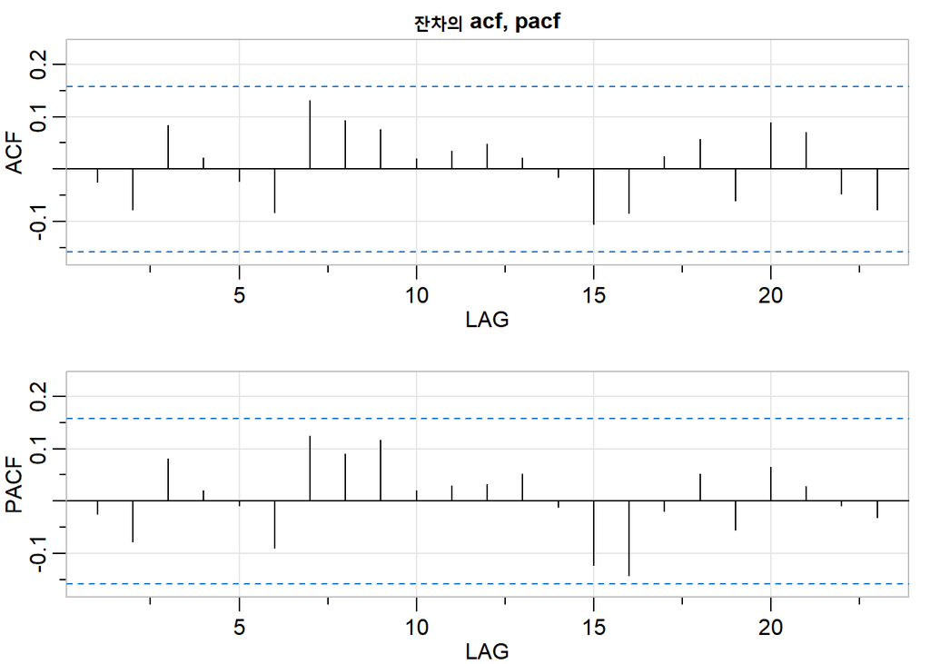

```
##       [,1]  [,2] [,3] [,4]  [,5]  [,6] [,7] [,8] [,9] [,10] [,11] [,12] [,13]
## ACF  -0.02 -0.08 0.08 0.02 -0.02 -0.08 0.13 0.09 0.08  0.02  0.03  0.05  0.02
## PACF -0.02 -0.08 0.08 0.02 -0.01 -0.09 0.12 0.09 0.12  0.02  0.03  0.03  0.05
##      [,14] [,15] [,16] [,17] [,18] [,19] [,20] [,21] [,22] [,23]
## ACF  -0.02 -0.11 -0.08  0.02  0.06 -0.06  0.09  0.07 -0.05 -0.08
## PACF -0.01 -0.12 -0.14 -0.02  0.05 -0.06  0.06  0.03 -0.01 -0.03
```

```r
acf2(resid(fit),main="잔차의 acf, pacf") # 다 신뢰구간 내에 존재함
```

```r
Box.test(resid(fit),lag=10,type="Ljung-Box")
```

```
##
##  Box-Ljung test
##
## data:  resid(fit)
## X-squared = 9.0404, df = 10, p-value = 0.5283
```

- 귀무가설을 기각하지 못하므로, 자기상관성이 없다고 할 수 있다. -> 백색잡음이다.

#### 과대적합

AR(3), ARMA(2,1) 모형을 적합시켜 총 3가지 모형을 비교해보자

```r
fit2<-arima(oil.price2, order=c(3,0,0)) #AR(3)
fit3<-arima(oil.price2, order=c(2,0,1)) #ARMA(2,1)
#AR(3)
summary(fit2)
```

```
##
## Call:
## arima(x = oil.price2, order = c(3, 0, 0))
##
## Coefficients:
##          ar1      ar2     ar3  intercept
##       1.3667  -0.6061  0.0967    19.1219
## s.e.  0.0822   0.1306  0.0846     0.8059
##
## sigma^2 estimated as 2.187:  log likelihood = -290.7,  aic = 589.41
##
## Training set error measures:
```

```
##               ME RMSE MAE MPE MAPE
## Training set NaN  NaN NaN NaN  NaN
```

```r
coeftest(fit2)
```

```
##
## z test of coefficients:
##
##            Estimate Std. Error z value  Pr(>|z|)
## ar1        1.366725   0.082171 16.6326 < 2.2e-16 ***
## ar2       -0.606097   0.130607 -4.6406 3.474e-06 ***
## ar3        0.096749   0.084588  1.1438    0.2527
## intercept 19.121889   0.805924 23.7267 < 2.2e-16 ***
## ---
## Signif. codes:  0 '***' 0.001 '**' 0.01 '*' 0.05 '.' 0.1 ' ' 1
```

```r
#ARMA(2,1)
summary(fit3)
```

```
##
## Call:
## arima(x = oil.price2, order = c(2, 0, 1))
##
## Coefficients:
##          ar1      ar2     ma1  intercept
##       1.1107  -0.2899  0.2686    19.1195
## s.e.  0.1974   0.1838  0.2042     0.8122
##
## sigma^2 estimated as 2.181:  log likelihood = -290.49,  aic = 588.98
##
## Training set error measures:
```

```
##               ME RMSE MAE MPE MAPE
## Training set NaN  NaN NaN NaN  NaN
```

```r
coeftest(fit3)
```

```
##
## z test of coefficients:
##
##           Estimate Std. Error z value  Pr(>|z|)
## ar1        1.11072    0.19741  5.6266 1.838e-08 ***
## ar2       -0.28991    0.18378 -1.5775    0.1147
## ma1        0.26864    0.20418  1.3157    0.1883
## intercept 19.11950    0.81221 23.5401 < 2.2e-16 ***
## ---
## Signif. codes:  0 '***' 0.001 '**' 0.01 '*' 0.05 '.' 0.1 ' ' 1
```

- AR(3), ARMA(2,1)모두 유의하지 않은 모수들이 존재한다.
- AIC도 AR(2)모형이 가장 작다.
- AR(2)모형이 가장 적절한 것 같다!!

## 6. 모형적합2

다른 방법으로 모형을 적합해보자  
정상성을 검정하고 -> `auto.arima()`함수를 사용하여 최적 모형과 차수를 찾고 -> 모형을 통해 미래를 예측해보자  
`auto.arima()`함수는 AIC, BIC등을 기반으로 적합한 모형과 차수를 찾아주는 함수이다.

```r
auto.arima(oil.price2)
```

```
## Series: oil.price2
## ARIMA(2,0,0) with non-zero mean
##
## Coefficients:
##          ar1      ar2     mean
##       1.3267  -0.4835  19.1463
## s.e.  0.0746   0.0750   0.7397
##
## sigma^2 estimated as 2.247:  log likelihood=-291.35
## AIC=590.71   AICc=590.97   BIC=603.01
```

- AR(2) 산출되었다.

```r
fit <- Arima(oil.price2, c(2,0,0)) ##모형 적합
fit
```

```
## Series: oil.price2
## ARIMA(2,0,0) with non-zero mean
##
## Coefficients:
##          ar1      ar2     mean
##       1.3267  -0.4835  19.1463
## s.e.  0.0746   0.0750   0.7397
##
## sigma^2 estimated as 2.247:  log likelihood=-291.35
## AIC=590.71   AICc=590.97   BIC=603.01
```

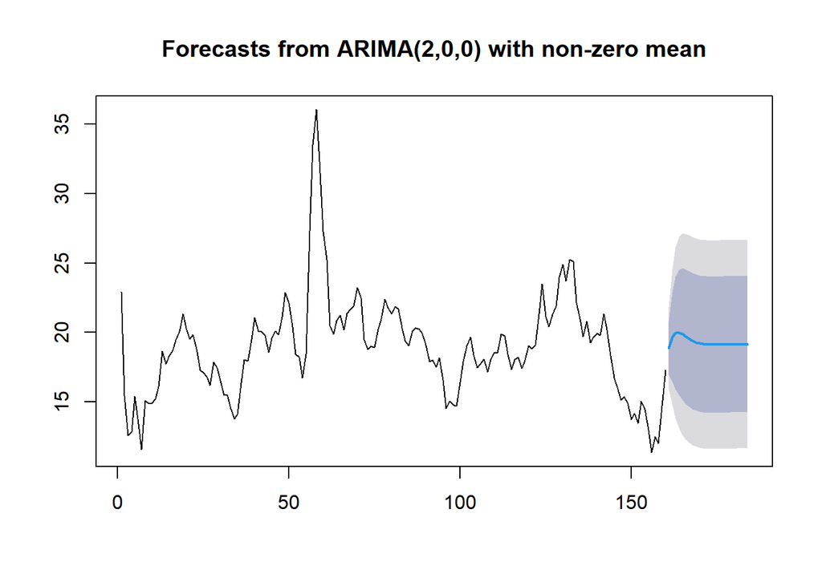

```r
plot(forecast(fit,h=24))
```

`sarima.for(data n.ahead, p, d, q)`를 사용해보자!  
여기서 `n.ahead`는 몇시점 뒤까지 예측 할 것인지 결정하는 인자이다.

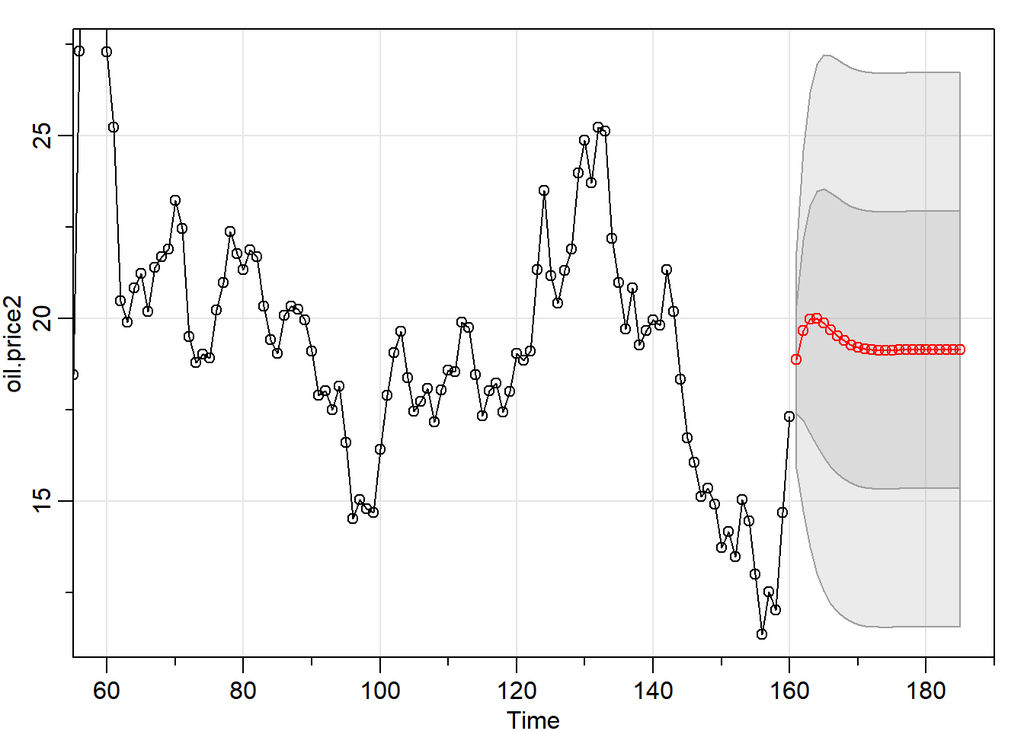

```
## $pred
## Time Series:
## Start = 161
## End = 185
## Frequency = 1
##  [1] 18.86962 19.66712 19.97106 19.98869 19.86512 19.69266 19.52359 19.38269
##  [9] 19.27749 19.20605 19.16214 19.13843 19.12820 19.12610 19.12825 19.13212
## [17] 19.13622 19.13978 19.14253 19.14445 19.14567 19.14636 19.14669 19.14679
## [25] 19.14676
##
## $se
## Time Series:
## Start = 161
## End = 185
## Frequency = 1
##  [1] 1.484881 2.466943 3.111163 3.481463 3.668470 3.750192 3.780017 3.788425
##  [9] 3.789894 3.789937 3.790034 3.790298 3.790579 3.790786 3.790907 3.790965
## [17] 3.790988 3.790995 3.790997 3.790997 3.790997 3.790997 3.790997 3.790997
## [25] 3.790998
```

```r
sarima.for(oil.price2, 25, 2,0,0)
```

## 7. 모형 적합3

1주차 실습에 사용한 `AirPassengers`데이터 사용해보자

```r
data <- AirPassengers
dc.m <- decompose(data, type="multiplicative")
dat <- dc.m$random[complete.cases(dc.m$random)]
auto.arima(dat)
```

```
## Series: dat
## ARIMA(3,0,1) with non-zero mean
##
## Coefficients:
##          ar1      ar2      ar3      ma1    mean
##       1.1189  -0.2467  -0.2238  -0.8513  0.9989
## s.e.  0.1012   0.1322   0.0915   0.0668  0.0011
##
## sigma^2 estimated as 0.0007906:  log likelihood=286.1
## AIC=-560.2   AICc=-559.53   BIC=-542.91
```

```r
fit <- Arima(dat,order=c(3,0,1))
```

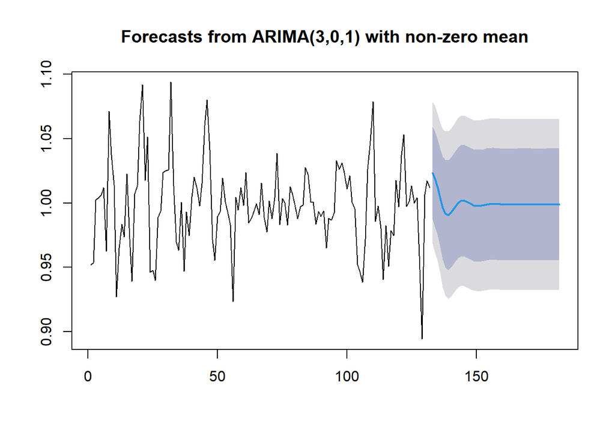

```r
plot(forecast(fit, h=50))
```

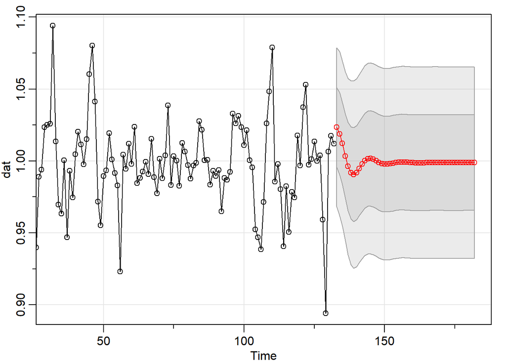

```
## $pred
## Time Series:
## Start = 133
## End = 182
## Frequency = 1
##  [1] 1.0233897 1.0189050 1.0122793 1.0034404 0.9961890 0.9917391 0.9905276
##  [8] 0.9918928 0.9947152 0.9978076 1.0002657 1.0016215 1.0018398 1.0011995
## [15] 1.0001257 0.9990333 0.9982193 0.9978183 0.9978151 0.9980925 0.9984935
## [22] 0.9988744 0.9991396 0.9992526 0.9992283 0.9991140 0.9989667 0.9988356
## [29] 0.9987508 0.9987212 0.9987384 0.9987839 0.9988372 0.9988818 0.9989083
## [36] 0.9989150 0.9989061 0.9988884 0.9988694 0.9988545 0.9988464 0.9988453
## [43] 0.9988494 0.9988561 0.9988628 0.9988678 0.9988701 0.9988701 0.9988683
## [50] 0.9988658
##
## $se
## Time Series:
## Start = 133
## End = 182
## Frequency = 1
##  [1] 0.02757917 0.02854917 0.02858611 0.02928679 0.03067836 0.03196428
##  [7] 0.03259151 0.03271684 0.03271902 0.03281844 0.03299443 0.03313914
## [13] 0.03320252 0.03321143 0.03321315 0.03322900 0.03325203 0.03326879
## [19] 0.03327506 0.03327558 0.03327611 0.03327852 0.03328148 0.03328338
## [25] 0.03328397 0.03328399 0.03328411 0.03328446 0.03328483 0.03328504
## [31] 0.03328509 0.03328509 0.03328511 0.03328516 0.03328521 0.03328523
## [37] 0.03328523 0.03328523 0.03328524 0.03328525 0.03328525 0.03328525
## [43] 0.03328525 0.03328525 0.03328525 0.03328525 0.03328526 0.03328526
## [49] 0.03328526 0.03328526
```

```r
sarima.for(dat, 50, 3,0,1)
```